# Exploring Loan Data

Hailu Teju

July 13, 2018

## Abstract

In this project I will explore relationships between borrowers’ credit scores and the APRs (annual percentage rates) on their loans, and whether or not there are relationships between variables such as income, employment status, credit score, APR, and delinquency.

## Introduction

For this exploration I will use [Loan Data from Prosper](https://www.google.com/url?q=https://s3.amazonaws.com/udacity-hosted-downloads/ud651/prosperLoanData.csv&sa=D&ust=1531485914213000). This data set contains 113,937 loans with 81 variables on each loan, including loan amount, borrower interest rate, borrower income, borrower employment status, and borrower credit history.

I begin this exploration with a preconceived intuition that people with better credit ratings will get loans with lower APRs and that people with better income and/or better employment status would fare better in terms of their credit scores and in turn in terms of getting loans with lower APRs. I also hold an intuition that borrowers with higher income will fare better in terms of delinquency on their loans. I will try to see if the data set confirms these intuitions.

# Univariate Plots

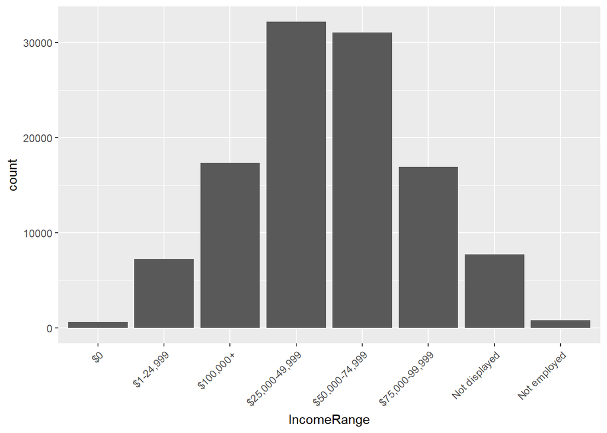

**IncomeRange** is a factor variable in the loan data set. But as we see in this plot the levels of this factor variable don’t seem to be ordered according to income. I will order the levels of the income variable in the tidying phase of my analysis. Also there are observations where **IncomeRange** is “Not displayed” and where it is “$0.” I will remove these observations later for a cleaner analysis. Otherwise, the majority of borrowers seem to be in the middle income brackets as expected.

```
## # A tibble: 2 x 2
##   IsBorrowerHomeowner Count
##                <fctr> <int>
## 1               False 56459
## 2                True 57478
```

The table above for the **IsBorrowerHomeowner** variable shows that the loan data set is split almost 50-50 into homeowners and non homeoweners.

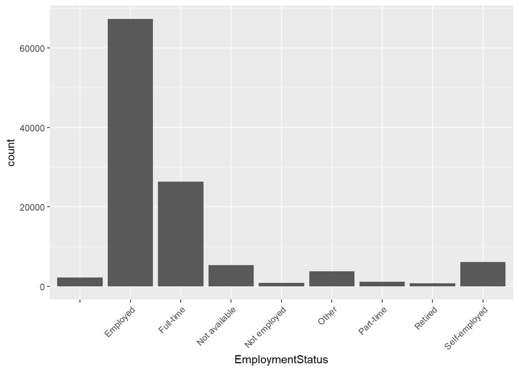

Looking into the **EmploymentStatus** variable, we see that there are some observations where the employment status is “Not available” or **NaN.** I will remove these observations from the data set. I am also not sure why there is a distinction between the levels “Employed” and “Full-time” of the factor variable **EmploymentStatus** (I will leave that as it is). Other than that, it appears that the majority of people are employed or have full-time jobs.

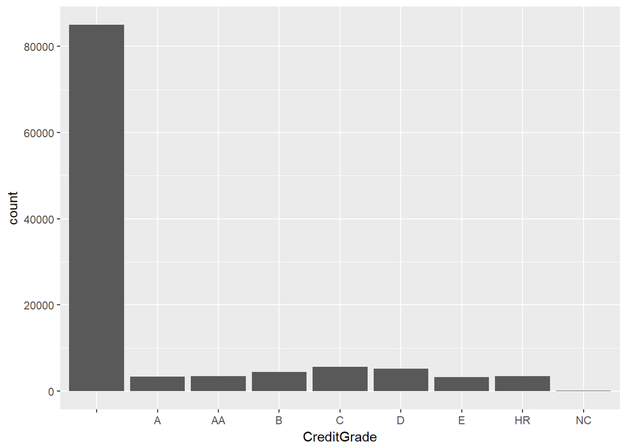

Here we see a lot of borrowers for whom credit grade is not available. Unfortunately, I will omit these substantial number of observations from the data set so as to have a good understanding of the relationships between credit score and other variables.

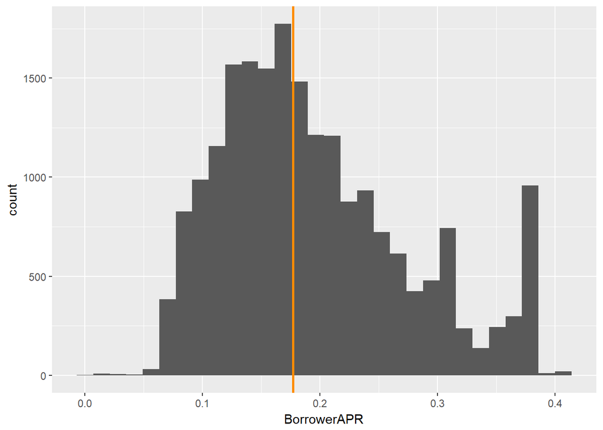

```
##   BorrowerAPR
##  Min.   :0.00653
##  1st Qu.:0.13504
##  Median :0.17722
##  Mean   :0.19478
##  3rd Qu.:0.24250
##  Max.   :0.41355
```

I am very surprised by what I have found in the above plot and the summary of the **BorrowerAPR** variable. The orange vertical line in the plot indicates where the median APR lies. The median APR for all borrowers (after the data set has been cleaned) is about $18\%.$ Furthermore, borrower’s APRs can go as high as $41.36\%.$ I found these to be very high figures and unexpected. Loans with such APRs, especially those toward the higher end, can be very costly to borrowers and can make it huge struggles for borrowers to pay off their loans.

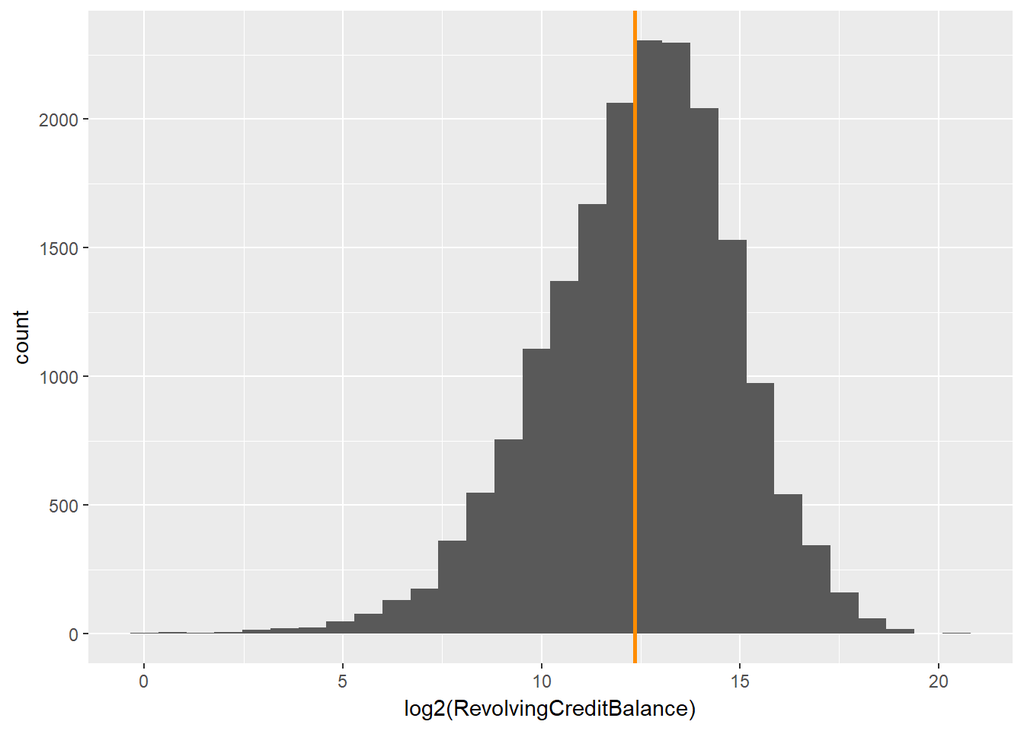

```
##  RevolvingCreditBalance
##  Min.   :      0
##  1st Qu.:   1203
##  Median :   5214
##  Mean   :  16014
##  3rd Qu.:  15466
##  Max.   :1435667
```

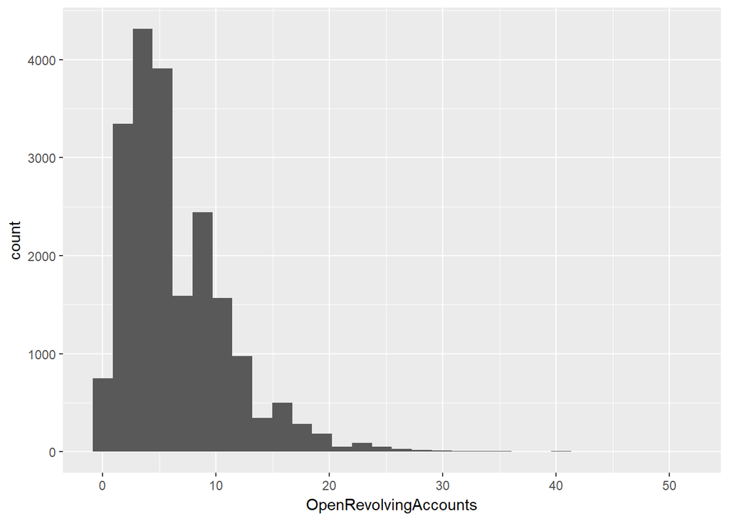

```
##  OpenRevolvingAccounts
##  Min.   : 0.000
##  1st Qu.: 3.000
##  Median : 5.000
##  Mean   : 6.345
##  3rd Qu.: 9.000
##  Max.   :51.000
```

Here we see that the median number of open revolving accounts for borrowers is 5, and the number could go as high as 51.

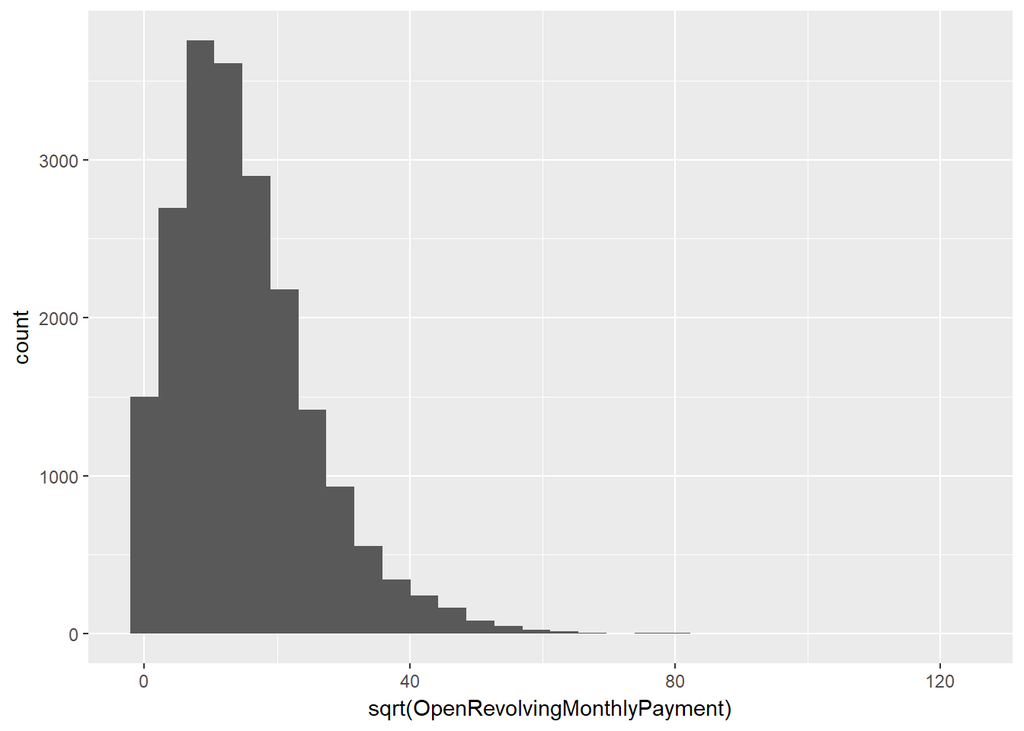

```
##  OpenRevolvingMonthlyPayment
##  Min.   :    0.0
##  1st Qu.:   56.0
##  Median :  173.0
##  Mean   :  339.9
##  3rd Qu.:  421.0
##  Max.   :14985.0
```

# Univariate Analysis

- The loan data set contains 113,937 loans with 81 variables on each loan (that is a lot of variables!). For the purpose of narrowing the focus of my analysis and getting closer to answering the questions I raised in my introduction, I will focus only on the variables I plotted above (and may be a few more) and their relationships in my bivariate and multivariate analysis below.
- I have transformed the income range factor variable to one that is an ordered factor variable according to income:

> $1-24,999 < $25,000-49,999 < $50,000-74,999 < $75,000-99,999 < $100,000+
- According to [Prosper API Definition - Details](https://www.prosper.com/Downloads/Services/Documentation/ProsperAPI_Objects_Details.html), the **CreditGrade** of the borrower is also an ordered factor variable with the following numerical values:

> 0 (NC), 1 (HR), 2 (E), 3 (D), 4 (C), 5 (B), 6 (A), and 7 (AA)
- I was also shocked by how high borrowers’ APRs (annual percentage rates) are in general and by the number of revolving accounts of some borrowers. Also, some borrowers have very large revolving credit balances and monthly payments.

# Bivariate Plots

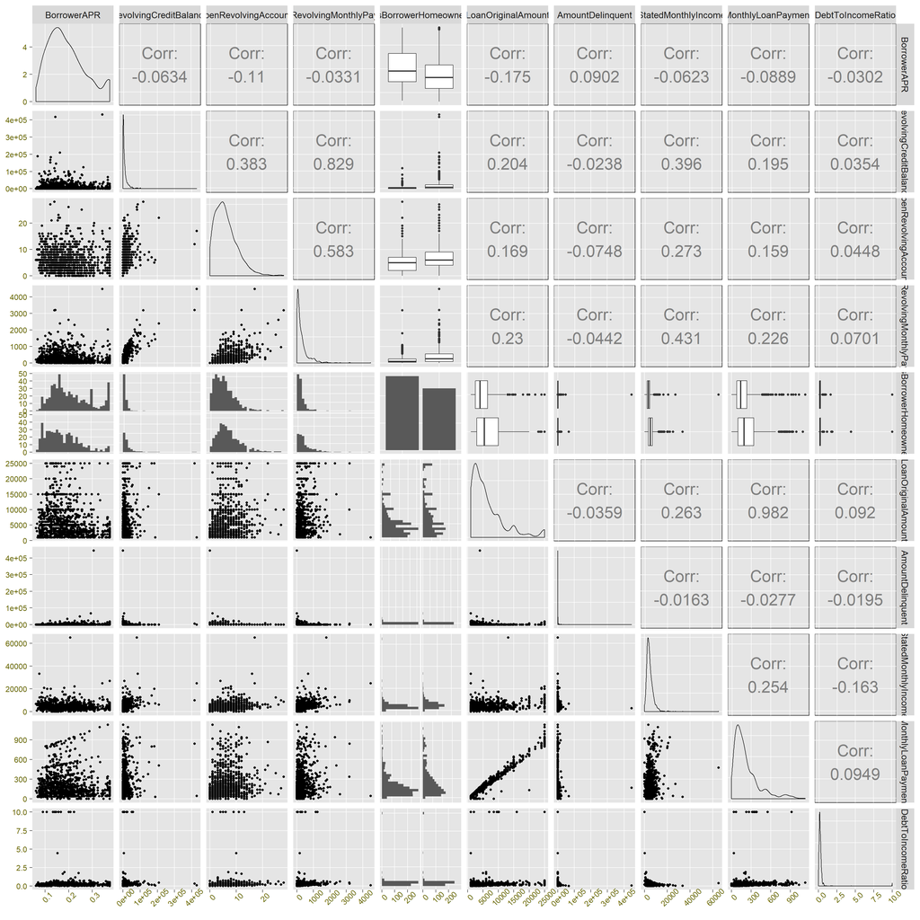

Here we see that there is a very strong correlation between original loan amount and monthly loan payment, revolving credit balance and revolving monthly payment, and there also seem to be correlation between number of open revolving accounts and revolving monthly payment, stated monthly income and revolving monthly payment, stated monthly income and revolving credit balance.

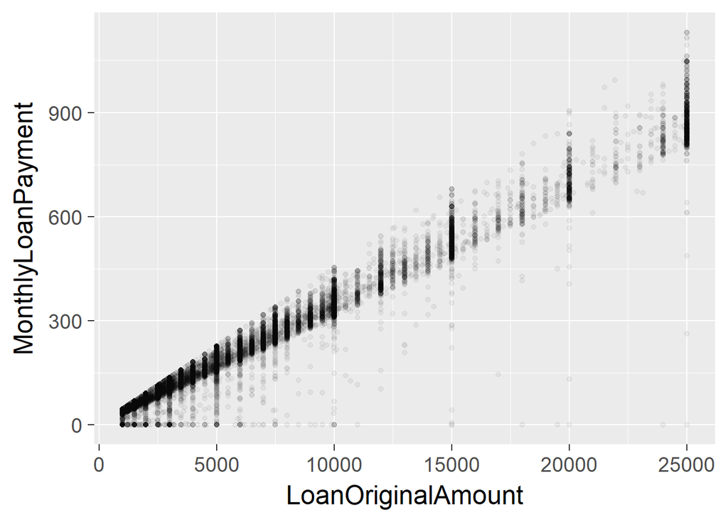

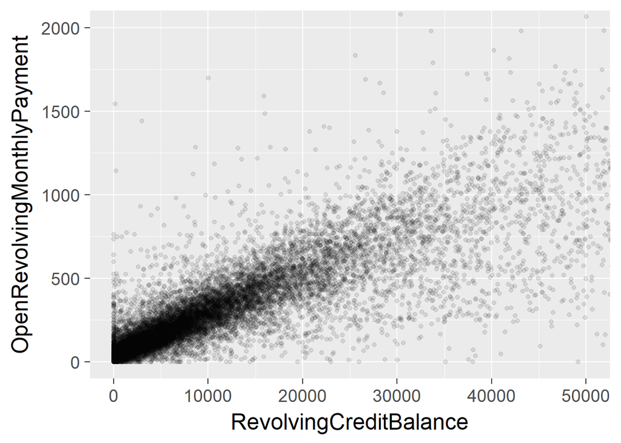

The two plots above confirm the strong correlations we observed in the pairs plot between the variables along the axes of the plots.

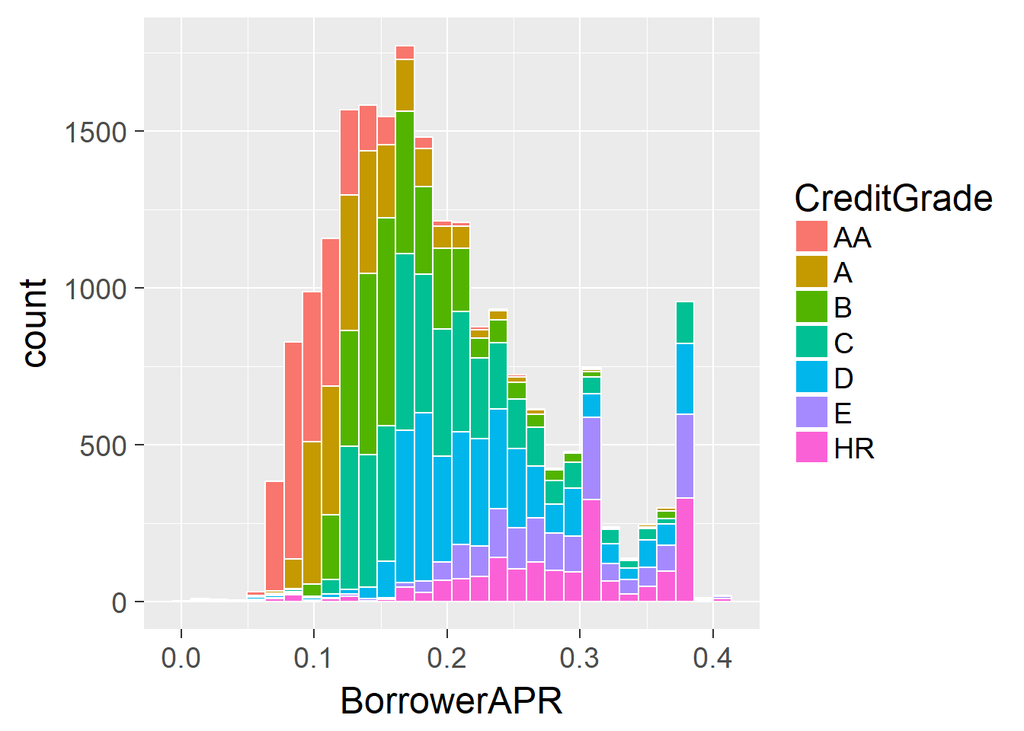

The above plot is a histogram for **BorrowerAPR** that we saw in the Univariate Plot section but colored using credit grade. This plot clearly shows that borrowers with better credit grades (recall that **HR < E < D < C < B < A < AA**) generally get lower APRs on their loans, which makes sense. To make this observation even more clear, I will facet the distribution plot for **BorrowerAPR** by **CreditGrade:**

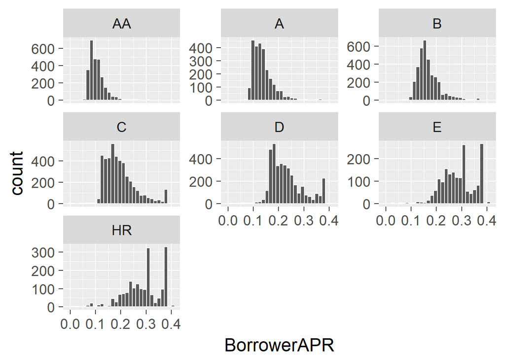

In these faceted plots, we can see that the better the credit grade of the borrower, the lower the borrower’s APR on their loan.

Next, I will use **IncomeRange** instead of **CreditGrade** to color the distribution plot for **BorrowerAPR** and see if there is any noticeable correlation between **IncomeRange** and **BorrowerAPR.**

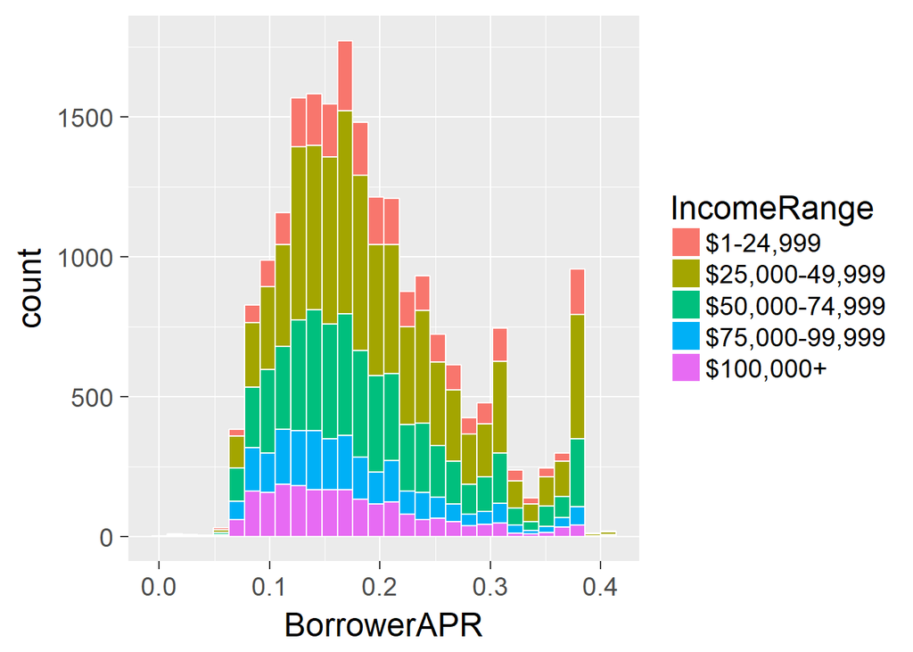

As we see, here there is no apparent correlation between **IncomeRange** and **BorrowerAPR** as all income ranges are spread out over the range of APR values. To make this even more clear, again I will facet the distribution plot for APR by income range:

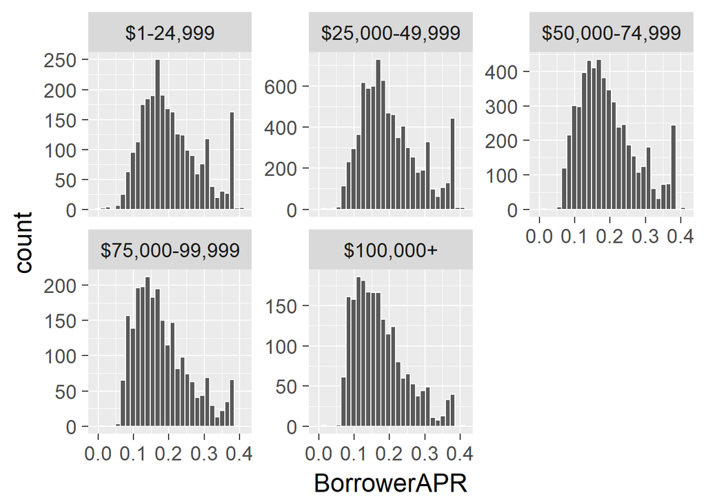

So, as stated above, borrowers have gotten varying levels of APR regardless of income range.

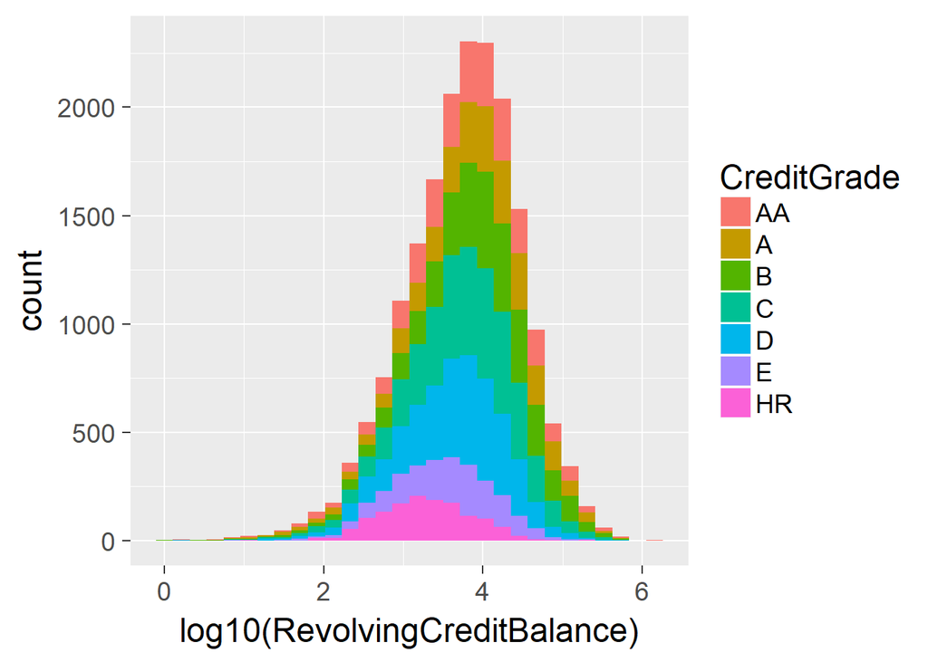

The above plot shows that one cannot infer anything about the borrower’s credit grade by only looking at the amount of their revolving credit balance. Later, I will use other types of plots techniques to see if there is some type of correlation between the two variables that can be uncovered by other means.

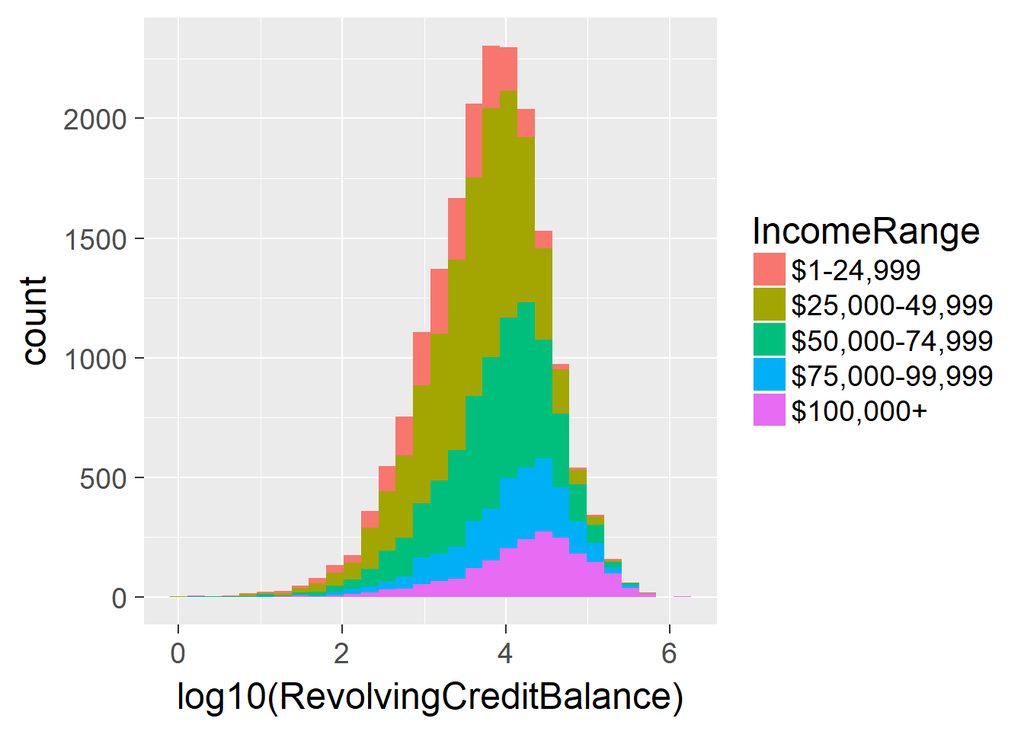

The amount of the borrower’s revolving credit balance, however, seems to be positively correlated with the borrower’s income range (though the correlation seems to be slightly weak); the higher the borrower’s income range, the larger the amount of the borrower’s revolving credit balance. Faceting the distribution plot for **log10(RevolvingCreditBalance)** by **IncomeRange** may give us a better view of this correlation.

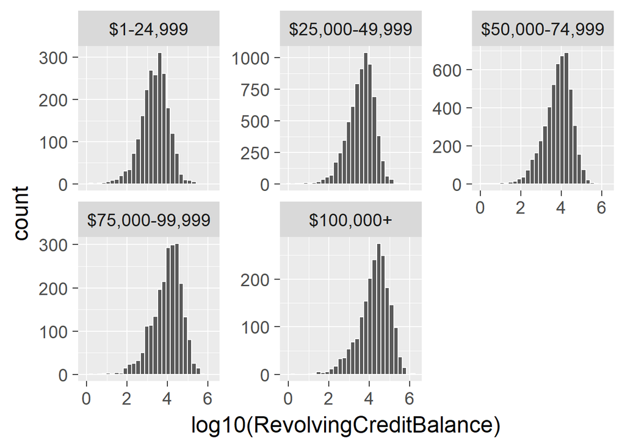

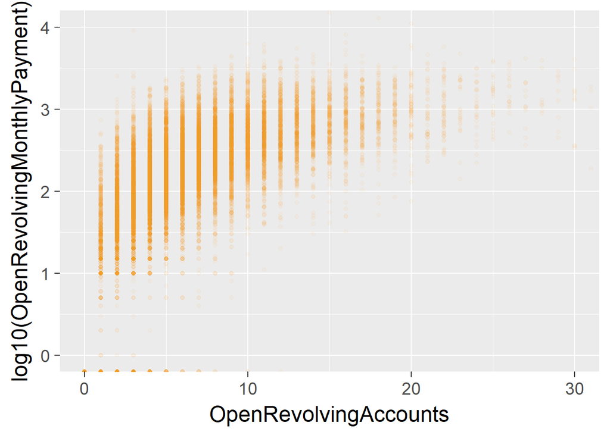

The vertical strips in the above plot show that **OpenRevolvingAccounts** takes on only integer values. Here, we also observe the positive correlation between number of open revolving accounts and open revolving monthly payment by the borrower that we also noticed from the pairs plot. Furthermore, we notice that variance of the open revolving monthly payment decreases as the nubmer of open revolving accounts increases.

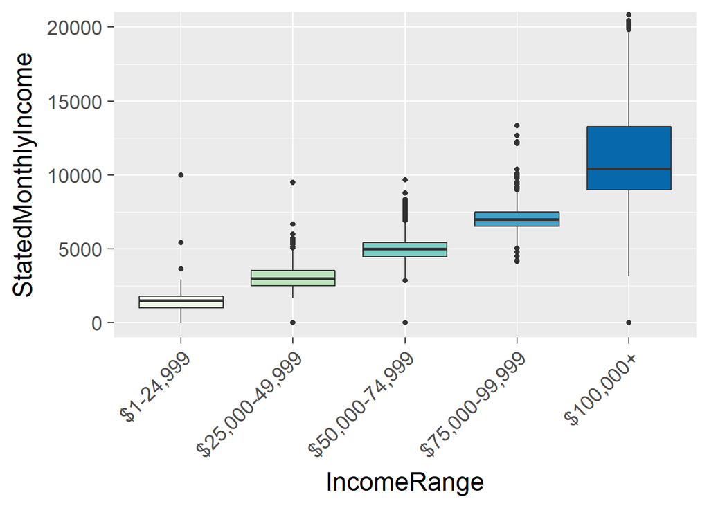

Not surprisingly, this boxplot shows that as income range increases, the stated monthly income also increases.

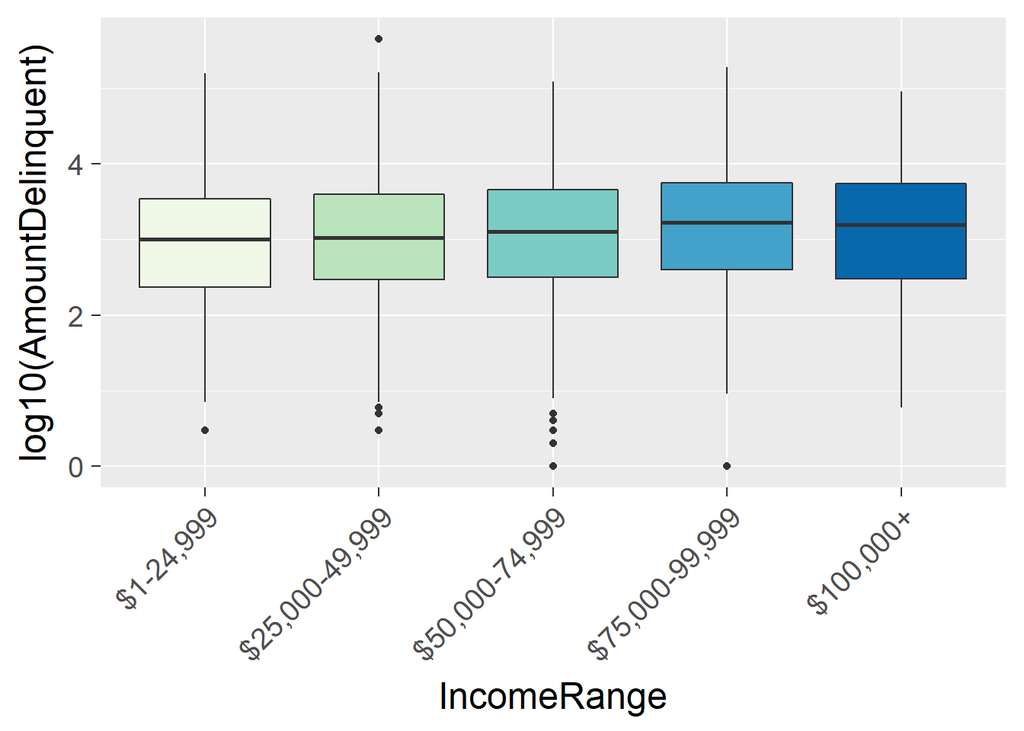

In the **log10(AmountDelinquent)** vs **IncomeRange** boxplot, we see that the higher the income range of the borrowers, the larger the median amount of delinquency. Well, this does not answer one of my questions in the introduction - can one say that the higher the income, the less likely the chance of delinquency (not concerning about the amount of delinquency)? To answer this question, I will create a new variable for the probability of delinquency by income range by divinding the number of delinquent accounts (regardless of the amount) in the income range by the total number of loans with non-missing observations.

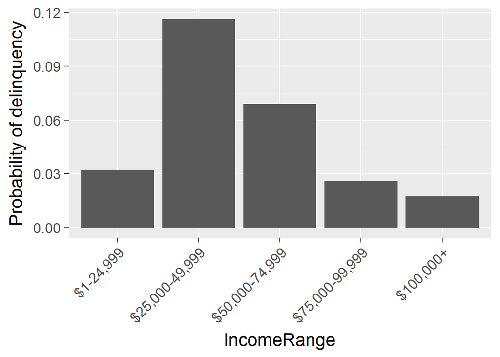

Sure enough, the above plot confirmed my initial intuition that the higher the income the smaller the probability of delinquency on loan (with the exception of the income range $1-24,999, where the probability of delinquency is relatively lower).

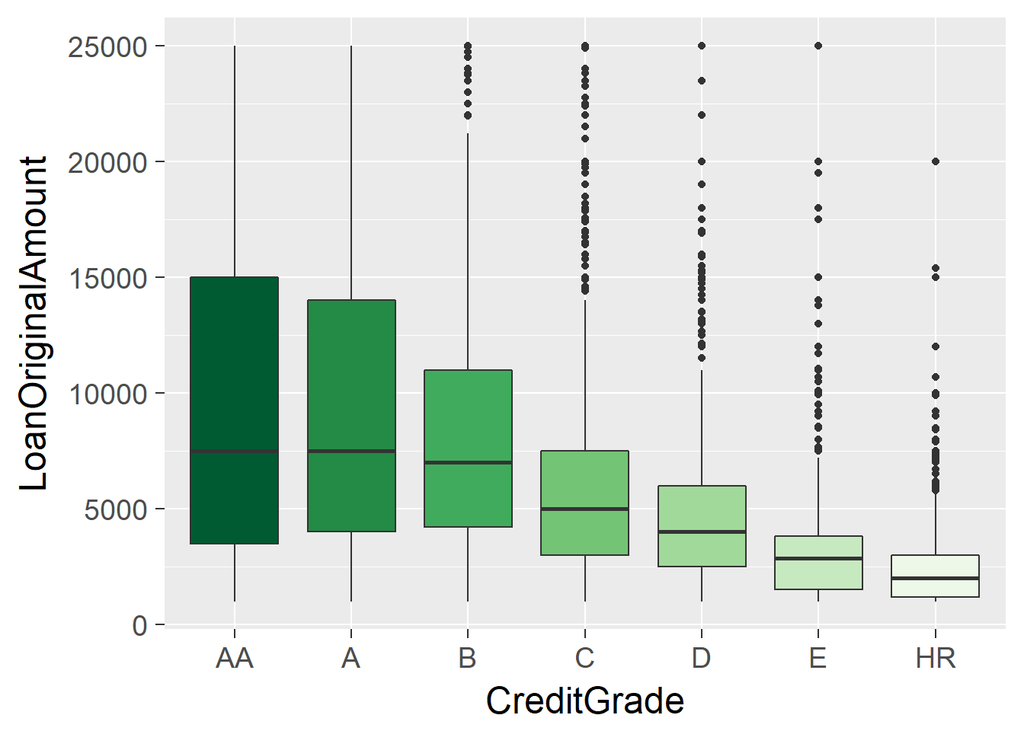

Here, we see that the better the credit grade of the borrower, the larger median of the original amount of loan the borrower got. Moreover, the IQR (inter quartile range) seems to increase with better credit grade, which suggests that the better the credit grade of the borrower the more options the borrower has on the original amount borrowed.

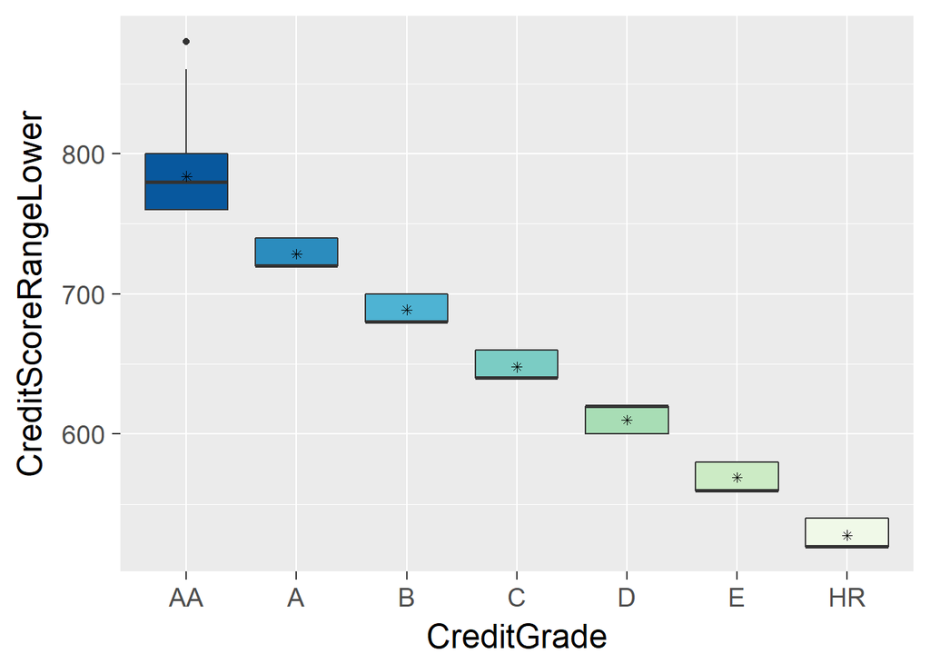

There is no surprise in what we see in the above boxplots. The better the credit grade of the borrower, the higher the lower level of their credit score range. I suspect that, in fact, credit grades are derived directly from credit score ranges using some sort of formula.

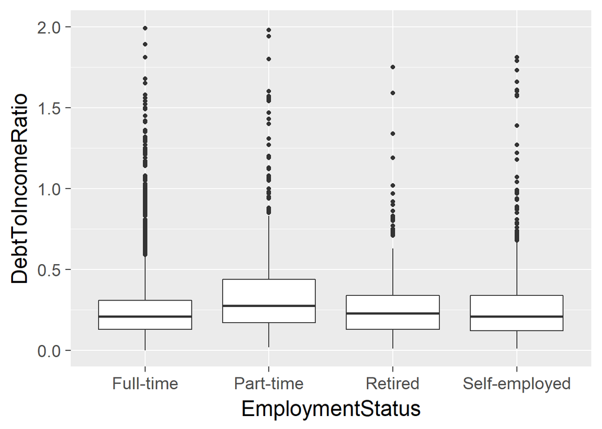

Another interesting insight is gained in the above boxplots. It appears that borrowers with part-time jobs seem to have a larger median debt-to-income ratio. This is not an unexpected observation as the borrower with a part-time job is less likely to generate more income than that needed to cover basic expenditures.

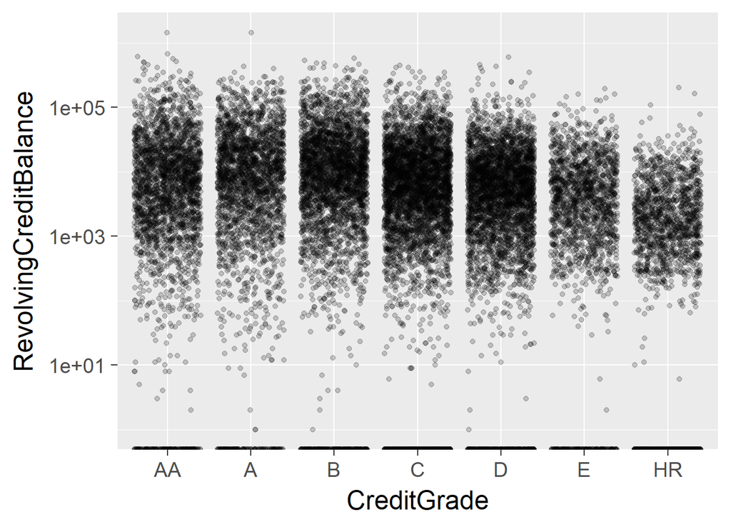

From the revolving credit balance vs. credit grade scatter plot above one can see that, generally, as the credit grade gets better, the revolving credit balance gets slightly higher. This indicates that having lower revolving credit balance in and of itself does not imply better credit grade.

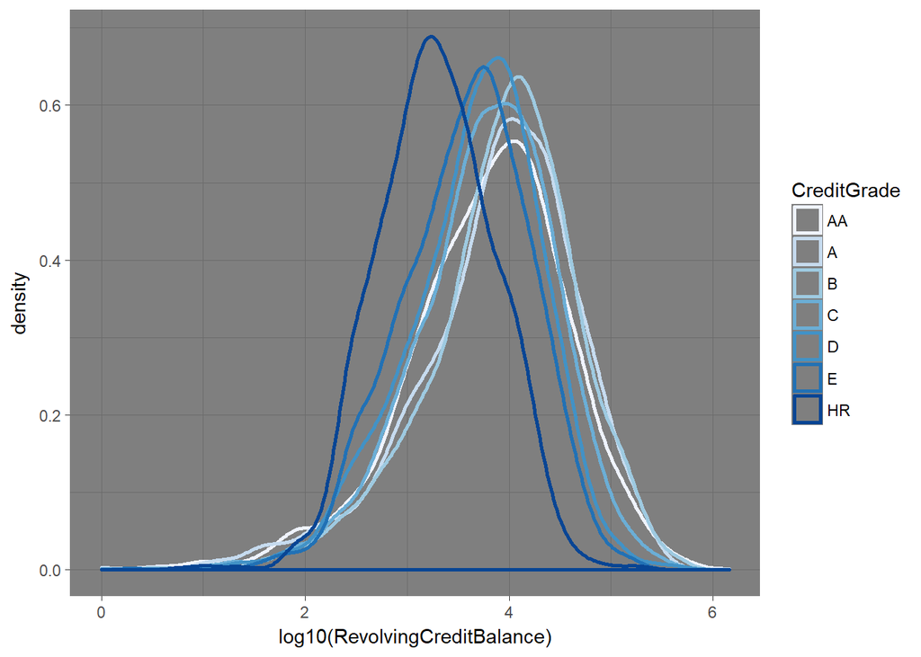

The density plot above confirms what we observed earlier in the **log10(RevolvingCreditBalance)** vs. **CreditGrade** scatter plot - that borrowers with better credit grades have generally slightly more revolving credit balances.

# Bivariate Analysis

- In the bivariate plots section above, I observed strong correlations between original loan amount and monthly loan payment, revolving credit balance and open revolving monthly payment, and also between credit grade and borrower’s APR (the better the credit grade the lower the borrower’s APR).
- I could also observe that the better the credit grade of the borrower, the larger the median of the original loan amount (and the larger the spread of the amount borrowed as well).
- Another interesting observation I made was that the higher the income range, the larger the median amount of delinquency. At first this observation seemed counter intuitive to me, but after thinking about it a bit more carefully, it made sense because, if one has a large income, then it is less likely that one would become delinquent over a small amount. That particuar plot did not answer one of my questions in the introduction - does higher income imply a lesser probability of delinquency? So, I created a new variable for the probability of delinquency by income range to help me answer this question. The histogram for the new (probability) variable that I created clearly answered this question in the afirmative - higher income indeed implies lesser chance of delinquency (with the exception of the income range $1-24,999, where the probability of delinquency is relatively lower).
- Another observation I was able to make from a bivariate plot was that part-time workers have the highest median debt-to-income ratio compared to borrowers in other employment status.

# Multivariate Plots

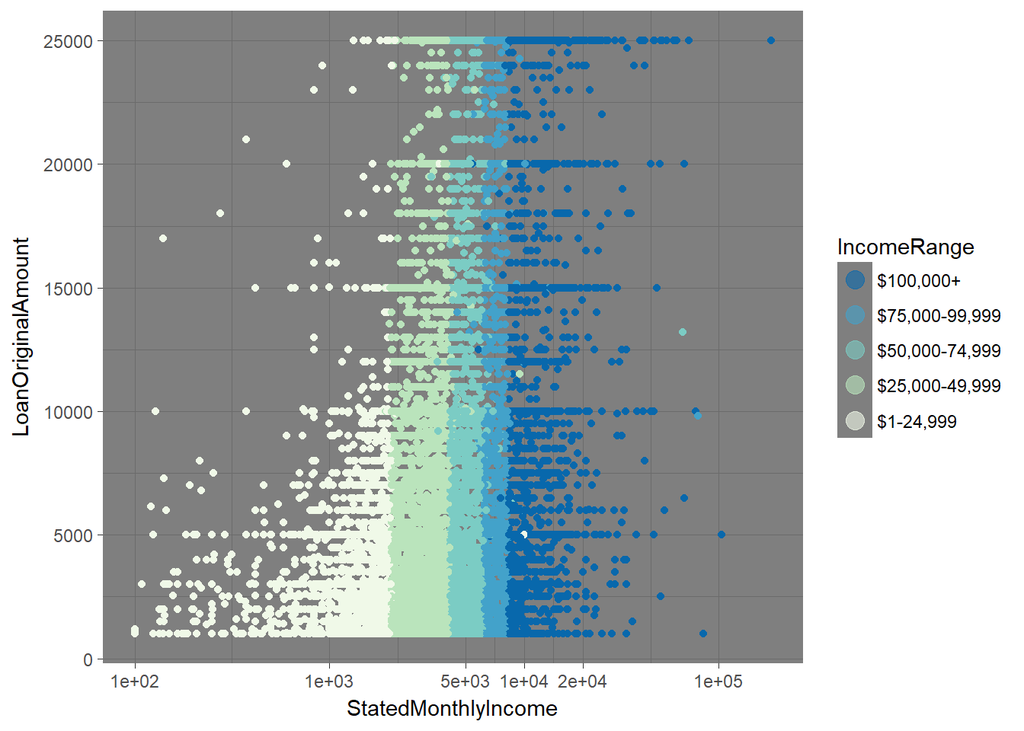

Here we see the relationships between three variables - **LoanOriginalAmount**, **StatedMonthlyIncome** and **IncomeRange**. As income range increases (and hence the stated monthly income increases - we’ve observed in the bivariate plot section that income range and stated monthly income are strongly positively correlated), the upper limit and the variance of the original loan amount increases. Similar relationships exist between the variables **LoanOriginalAmount**, **CreditScoreRangeLower** and **CreditGrade** as could be seen in the multivariate scatter plot below.

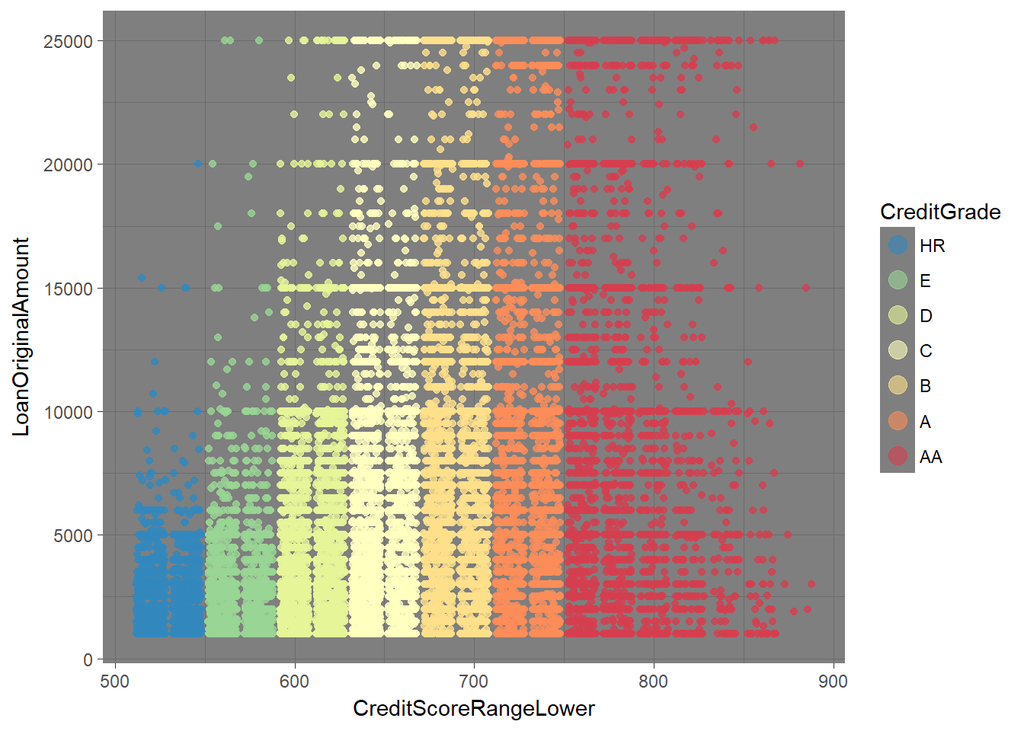

The above plot shows that there exists a strong positive correlation between the lower range of the borrower’s credit score and thier credit grade (we’d made this observation earlier in the bivariate plots section as well). Moreover, as the credit grade (hence the lower range of the borrower’s credit score) increases, the upper limit for the original loan amount and the variance of the original loan amount increase.

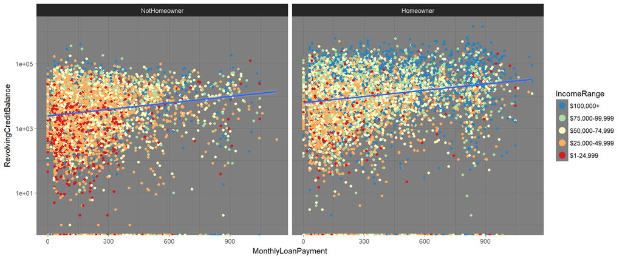

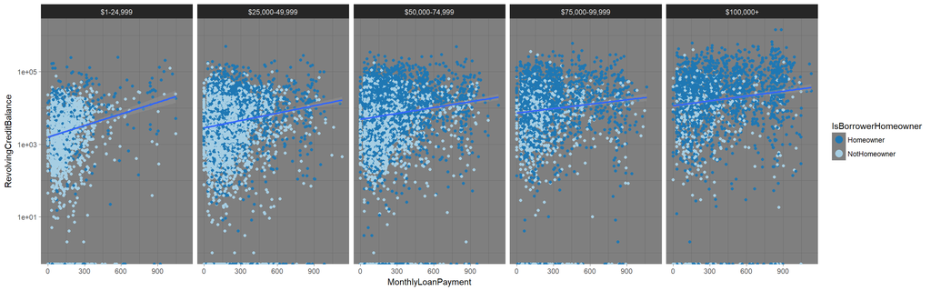

Each of the two plots above involves the same set of four variables - revolving credit balance, monthly loan payment, homeownership (a boolean variable) and income range. Some of the things we can observe from these plots are:

- homeowers seem to have slighly more revolving credit balance than non-homeowners
- most borrowers in the upper income range seem to be homeowners
- there exists a positive correlation between the amount of revolving credit balance of borrowers and their monthly loan payments (that is to be expected)
- we also notice the slightly weaker but positive correlation between income range and revolving credit balance (that we had observed ealier in the bivariate plot section).

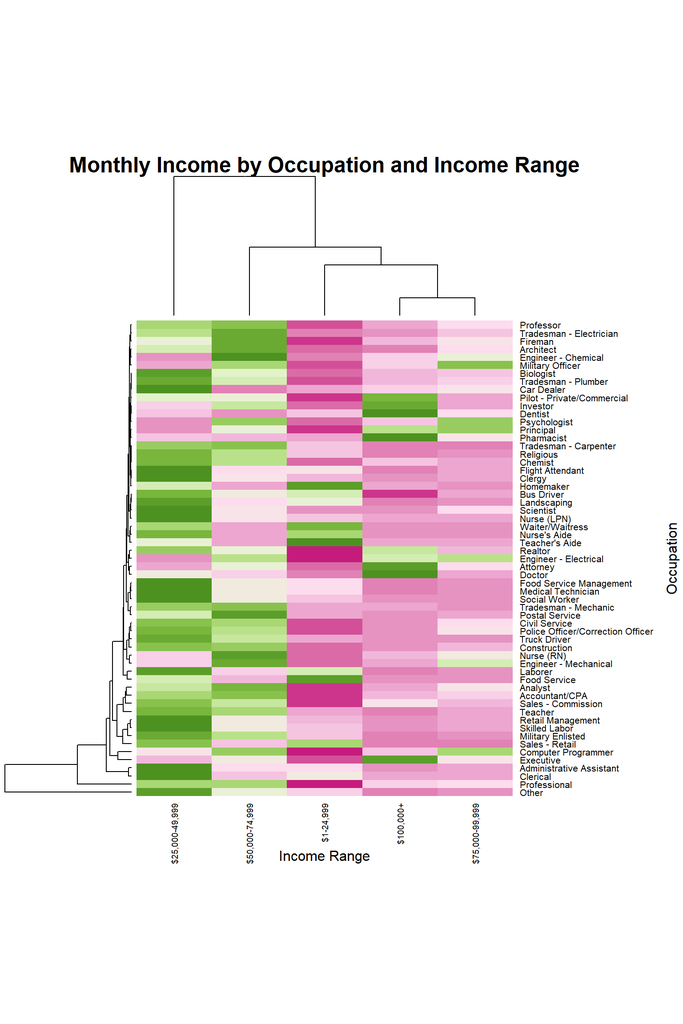

Lastly, I wanted to glean some information about the **Occupation** variable and its relationship with other variables such as income. Heatmap turned out to be the prefered method of visualization for this purpose becasue the **Occupation** variable is a categorical variable with many observations and hence, other visualization techniques seemed less conducive.

From the heatmap above, we can gather that borrowers with the majority of occupations belong to the middle income brackets.

- Homemaker, bus driver, landscaper, Waiter/Waitress, Nurse’s aide, Teacher’s aide, laborer, foodservice, and sales-retail occupations pay in the smaller income range.
- On the other hand, pilot-private/commercial, investor, dentist, principal, pharmacist, realtor, engineer, attorney, doctor, executive occupations pay in the top income range.